# AZMP Climatology report 2024

```r
library(librarian)
shelf(tidyverse, DT, ggplot2, oce, ocedata, plotly)
```

# Introduction

This report will outline the process to update the climatology used in the quality control of AZMP data in the Maritimes region. The climatology was last updated by Gordana Lazin in 2014.

# Geographic Bounds

37° N to 48° N and 71° W to 48° W The same range used by Lazin in 2014.

# Temporal Coverage

Extracted data after Jan 1 1999, to give a 25 year period of data.

# BioChem extraction

BioChem data was extracted May 1 , 2024.

Parameters were queried separately to ease processing burden due to file size.

Each parameter was queried based on - a bounding box of 37° N to 48° N and 71° W to 48° W - Mission start date after Jan 1, 1999

These tables include distinct replicate values where they exist.

See query scripts in sql_queries directory.

# Visualize scope of data

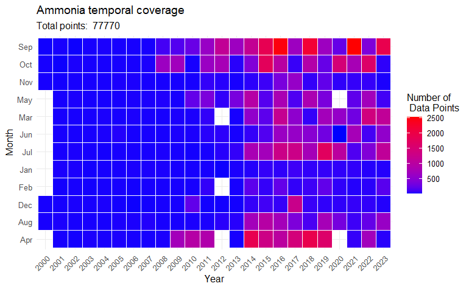

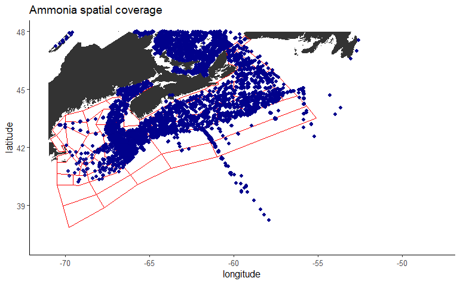

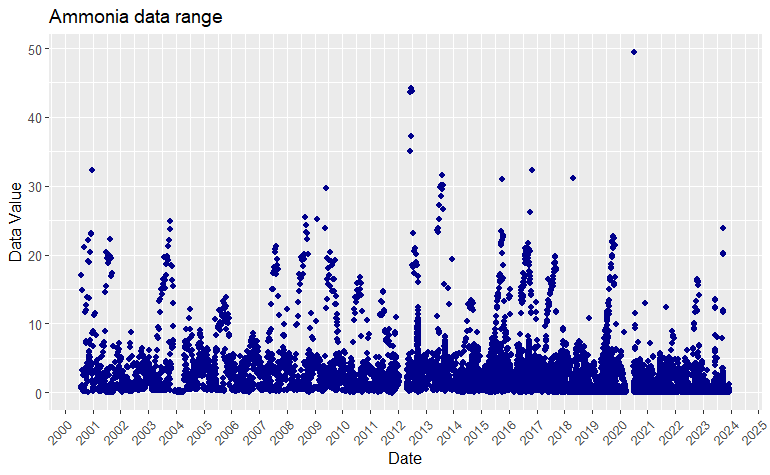

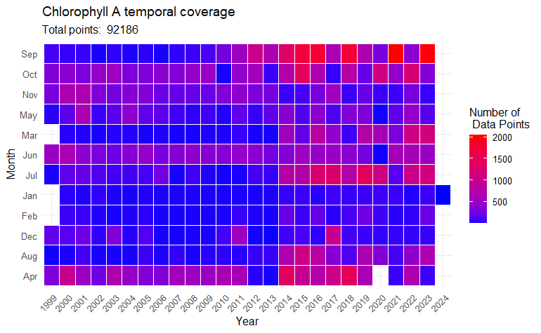

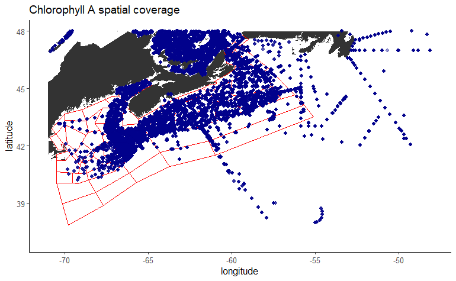

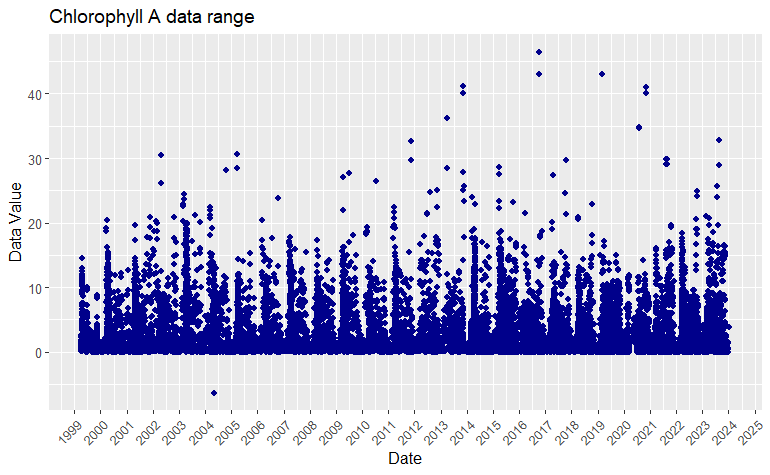

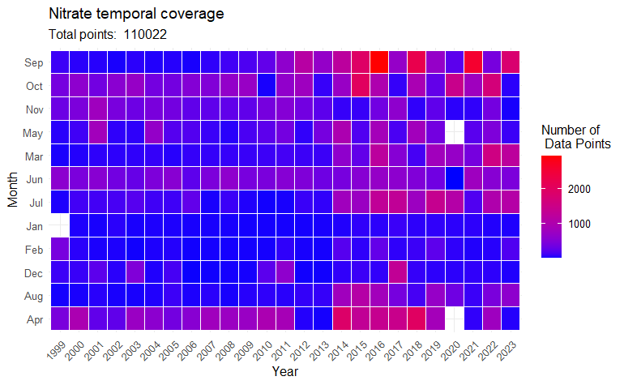

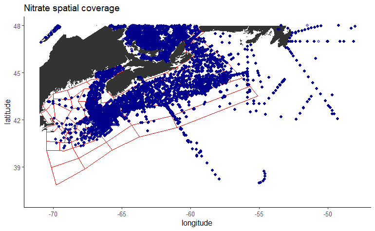

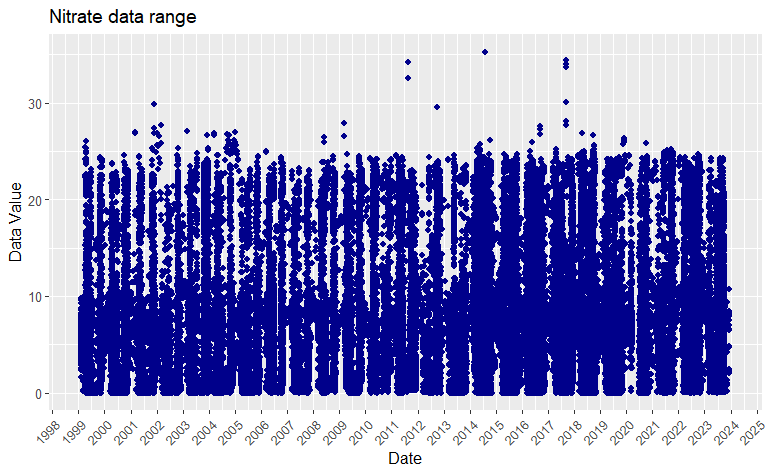

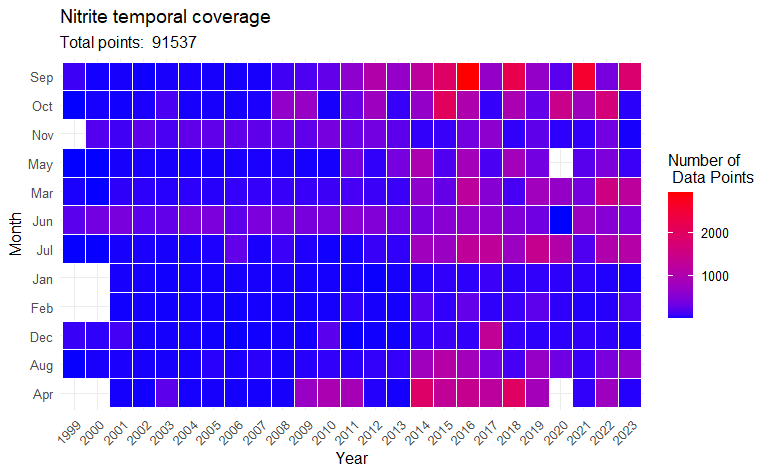

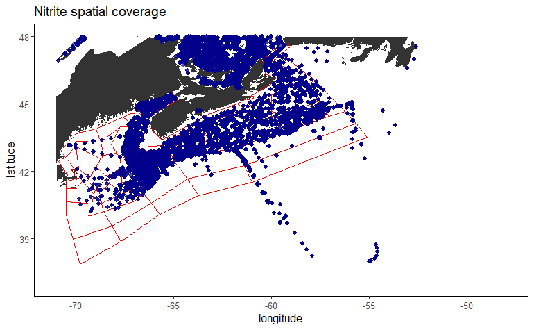

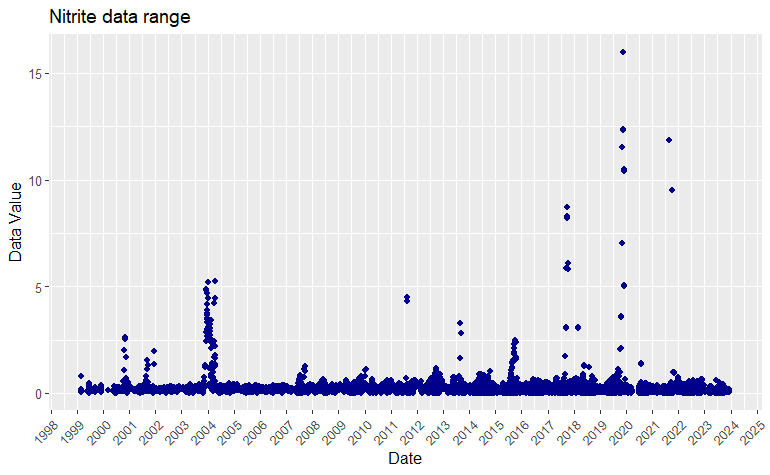

[12 more figures not shown]

```r
data_fns <- list.files('data/extractions/', pattern = '.csv', full.names = TRUE)

   # load in oce coastline
  data(coastlineWorldFine)
  clwf <- data.frame(coastlineWorldFine@data)

    # load in existing boxes
  polygons <- read.csv('data/Climate_ScotiaFundy_Polygons.csv')



for (i in 1:length(data_fns)) {

  data <- read.csv(data_fns[i])

  param_name <- unique(data$PARAMETER_NAME)

  # temporal coverage by year/month ----
  yearMonth <- data %>%
    mutate(., year = format(as.Date(data$EVENT_START, '%d-%b-%y'), '%Y')) %>%
    mutate(., month = format(as.Date(data$EVENT_START, '%d-%b-%y'), '%b')) %>%
    group_by(year, month) %>%
    summarise(N = n())

  p_temp <- ggplot(yearMonth, aes(year, month)) +
    geom_tile(aes(fill = N), colour = "white") +
    scale_fill_gradient(low = "blue", high = "red") +
    labs(x = "Year", y = "Month", fill = "Number of \n Data Points") +
    theme_minimal()+
    ggtitle(paste(param_name, "temporal coverage"), subtitle = paste("Total points: ", sum(yearMonth$N)))+
    theme(axis.text.x = element_text(angle = 45, hjust = 1))

    print(p_temp)

  # spatial coverage ----


  p_sp <- ggplot(data) +
    geom_polygon(data = clwf, aes(x = longitude, y = latitude)) +
    geom_polygon(data = polygons, aes(x = Longitude, y = Latitude, group = Area), color = "red", fill = NA)+
    geom_point(aes(x = HEADER_START_LON, y = HEADER_START_LAT), colour ='darkBlue', alpha = 0.4) +
    scale_x_continuous(limits = c(-71, -48))+
    scale_y_continuous(limits = c(37, 48)) +
    theme_classic()+
    ggtitle(paste(param_name, "spatial coverage"))

  print(p_sp)

  # raw value range ----
    # TODO check units on all params

  p_range <- ggplot(data) +
    geom_point(aes(x = as.Date(EVENT_START, '%d-%b-%y'),
                   y = DATA_VALUE),
               colour = 'darkBlue') +
    scale_x_date(date_breaks = "1 year", date_labels = '%Y')+
    labs(x = 'Date', y = 'Data Value')+
    theme(axis.text.x = element_text(angle = 45, hjust = 1))+
    ggtitle(paste(param_name, "data range"))



  print(p_range)
}
```

# Summary of data

These tables show all the methods (and their units), included in each parameter.

```r
data_fns <- list.files('data/extractions/', pattern = '.csv', full.names = TRUE)


for (i in 1:length(data_fns)) {

  data <- read.csv(data_fns[i])

  param_name <- unique(data$PARAMETER_NAME)

  methods <- data %>%
    distinct(METHOD, UNIT)


  print(knitr::kable(methods, col.names = c('Methods', 'Units'), caption = paste(param_name, 'methods & units')))
}
```

Ammonia methods & units

| Methods | Units |
| --- | --- |
| NH3_3 | milli mol/metre**3 |
| NH3_Tech_Fsh | milli mol/metre**3 |
| NH3_Tech_F | milli mol/metre**3 |
| NH3_0 | milli mol/metre**3 |

Chlorophyll A methods & units

| Methods | Units |
| --- | --- |
| Chl_a_Welschmeyer_sF | milligrams / metre**3 |
| Chl_a_Holm-Hansen_F | milligrams / metre**3 |
| Chl_a | milligrams / metre**3 |
| Chl_a_Holm-Hansen_sF | milligrams / metre**3 |
| Chl_a_Welsch_fresh | milligrams / metre**3 |
| Chl_a_H-H_fresh | milligrams / metre**3 |

Nitrate methods & units

| Methods | Units |
| --- | --- |
| NO2NO3_Tech_F | milli mol/metre**3 |
| NO2NO3_Tech_SF | milli mol/metre**3 |
| NO2NO3_Alp_SF | milli mol/metre**3 |
| NO2NO3_0 | milli mol/metre**3 |
| NO2NO3_Tech_Fsh | milli mol/metre**3 |
| NO2NO3_Tech2_F | milli mol/metre**3 |
| NO2NO3_Tech_Fsh_Norm | milli mol/metre**3 |
| NO3_Tech_SF | milli mol/metre**3 |
| NO3_Tech_F | milli mol/metre**3 |

Nitrite methods & units

| Methods | Units |
| --- | --- |
| NO2_Tech_F | milli mol/metre**3 |
| NO2_Tech_SF | milli mol/metre**3 |
| NO2_Alp_SF | milli mol/metre**3 |
| NO2_Tech_Fsh | milli mol/metre**3 |
| NO2_Tech_Fsh_Norm | milli mol/metre**3 |
| NO2_0 | milli mol/metre**3 |

O2 methods & units

| Methods | Units |
| --- | --- |
| O2_Winkler_Auto | milli mol/metre**3 |
| O2_Winkler | milli mol/metre**3 |

Phaeophytin methods & units

| Methods | Units |
| --- | --- |
| Phaeo_Holm-HansenF | milligrams / metre**3 |
| Phaeo | milligrams / metre**3 |
| Phaeo_Holm-Hansen | milligrams / metre**3 |
| Phaeo_H-H_fresh | milligrams / metre**3 |

Phosphate methods & units

| Methods | Units |
| --- | --- |
| PO4_Tech_F | milli mol/metre**3 |
| PO4_Tech2_F | milli mol/metre**3 |
| PO4_Tech_Fsh | milli mol/metre**3 |
| PO4_Tech_Fsh_Norm | milli mol/metre**3 |
| PO4_Tech_SF | milli mol/metre**3 |
| PO4_Alp_SF | milli mol/metre**3 |
| PO4_0 | milli mol/metre**3 |

Silicate methods & units

| Methods | Units |
| --- | --- |
| SiO4_Tech_F | milli mol/metre**3 |
| SiO4_Tech2_F | milli mol/metre**3 |
| SiO4_Tech_Fsh | milli mol/metre**3 |
| SiO4_Tech_Fsh_Norm | milli mol/metre**3 |
| SiO4_Tech_SF | milli mol/metre**3 |
| SiO4_Alp_SF | milli mol/metre**3 |
| SiO4_0 | milli mol/metre**3 |

```r
NA
NA
```

# Data Quality Summary

Quality overview, these tables show number and percentage of data points with each quality flag, by parameter.

```r
data_fns <- list.files('data/extractions/', pattern = '.csv', full.names = TRUE)


for (i in 1:length(data_fns)) {

  data <- read.csv(data_fns[i])

  param_name <- unique(data$PARAMETER_NAME)

  qc_summ <- data %>%
    group_by(DATA_QC_CODE) %>%
    summarize(Count = n())%>%
    mutate(Percentage = round(Count / sum(Count) * 100, 2))

  print(knitr::kable(qc_summ, caption = paste(param_name, "Quality Summary")))

}
```

Ammonia Quality Summary

| DATA_QC_CODE | Count | Percentage |
| --- | --- | --- |
| 0 | 66495 | 85.50 |
| 1 | 4375 | 5.63 |
| 2 | 163 | 0.21 |
| 3 | 720 | 0.93 |
| 4 | 1463 | 1.88 |
| 5 | 30 | 0.04 |
| 6 | 4524 | 5.82 |

Chlorophyll A Quality Summary

| DATA_QC_CODE | Count | Percentage |
| --- | --- | --- |
| 0 | 17314 | 18.78 |
| 1 | 73837 | 80.10 |
| 2 | 86 | 0.09 |
| 3 | 635 | 0.69 |
| 4 | 219 | 0.24 |
| 5 | 95 | 0.10 |

Nitrate Quality Summary

| DATA_QC_CODE | Count | Percentage |
| --- | --- | --- |
| 0 | 16517 | 15.01 |
| 1 | 89720 | 81.55 |
| 2 | 472 | 0.43 |
| 3 | 994 | 0.90 |
| 4 | 374 | 0.34 |
| 5 | 78 | 0.07 |
| 6 | 1867 | 1.70 |

Nitrite Quality Summary

| DATA_QC_CODE | Count | Percentage |
| --- | --- | --- |
| 0 | 15816 | 17.28 |
| 1 | 71522 | 78.13 |
| 2 | 64 | 0.07 |
| 3 | 349 | 0.38 |
| 4 | 356 | 0.39 |
| 5 | 78 | 0.09 |
| 6 | 3352 | 3.66 |

O2 Quality Summary

| DATA_QC_CODE | Count | Percentage |
| --- | --- | --- |
| 0 | 3238 | 18.16 |
| 1 | 13683 | 76.75 |
| 2 | 593 | 3.33 |
| 3 | 112 | 0.63 |
| 4 | 203 | 1.14 |

Phaeophytin Quality Summary

| DATA_QC_CODE | Count | Percentage |
| --- | --- | --- |
| 0 | 67965 | 93.63 |
| 1 | 4323 | 5.96 |
| 2 | 2 | 0.00 |
| 3 | 62 | 0.09 |
| 4 | 67 | 0.09 |
| 5 | 4 | 0.01 |
| 6 | 168 | 0.23 |

Phosphate Quality Summary

| DATA_QC_CODE | Count | Percentage |
| --- | --- | --- |
| 0 | 16597 | 15.13 |
| 1 | 90571 | 82.55 |
| 2 | 167 | 0.15 |
| 3 | 1633 | 1.49 |
| 4 | 433 | 0.39 |
| 5 | 78 | 0.07 |
| 6 | 242 | 0.22 |

Silicate Quality Summary

| DATA_QC_CODE | Count | Percentage |
| --- | --- | --- |
| 0 | 18626 | 17.06 |
| 1 | 88940 | 81.47 |
| 2 | 305 | 0.28 |
| 3 | 617 | 0.57 |
| 4 | 333 | 0.31 |
| 5 | 78 | 0.07 |
| 6 | 264 | 0.24 |

```r
NA
NA
NA
```

# Quality Flagged Profile Plots

Profile plots for all data of each parameter, where colours show data quality flag.

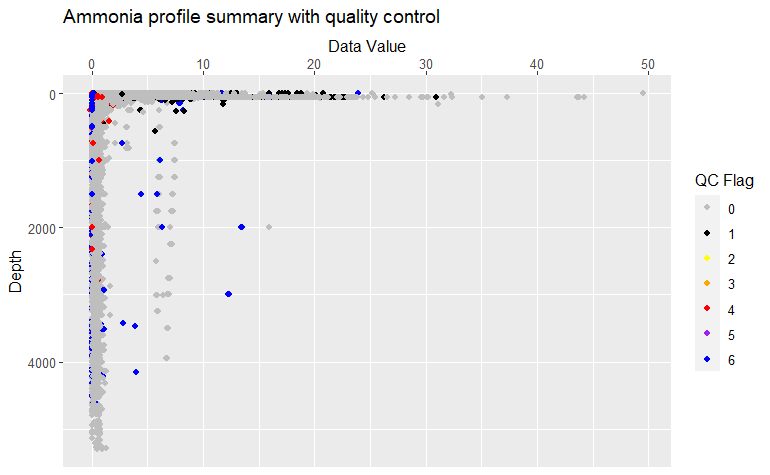

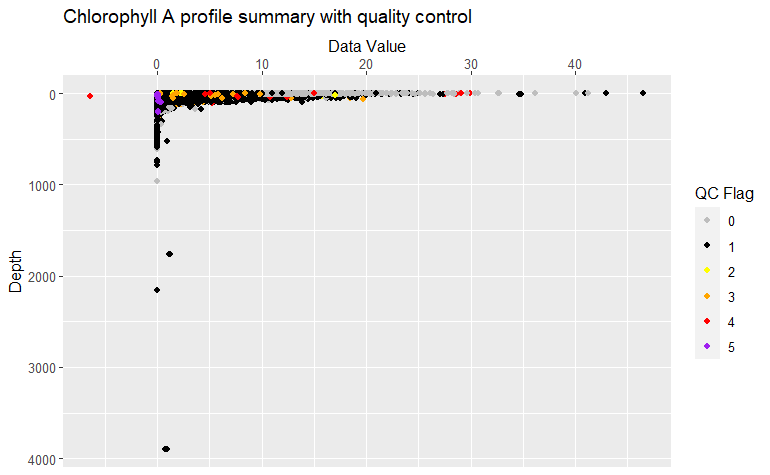

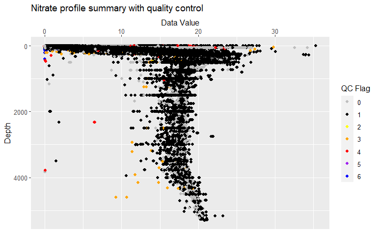

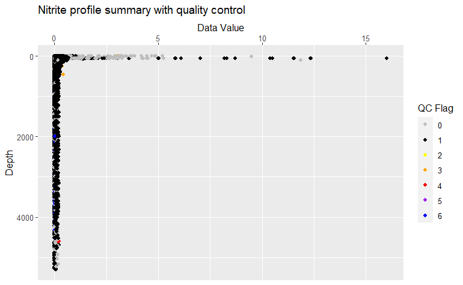

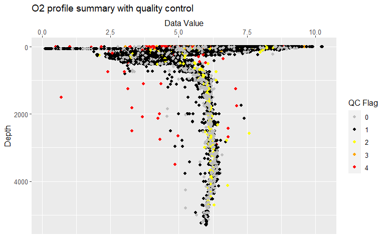

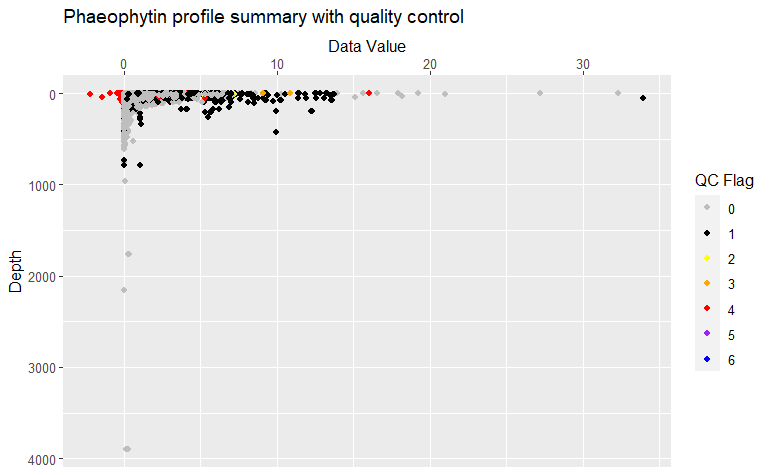

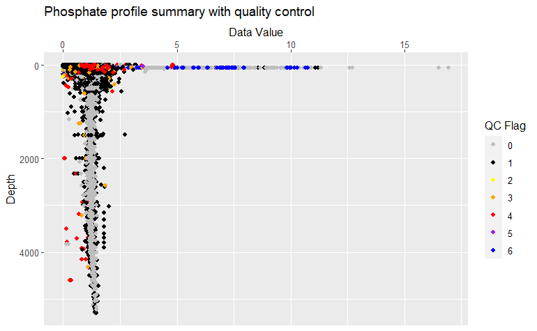

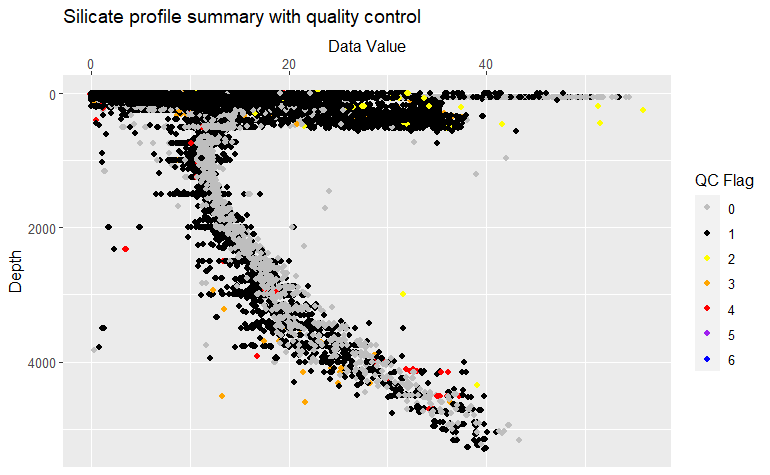

```r
data_fns <- list.files('data/extractions/', pattern = '.csv', full.names = TRUE)

col_vec = c('grey', 'black', 'yellow', 'orange', 'red', 'purple', 'blue', 'springgreen', 'cyan', 'magenta')
names(col_vec) <- c('0', '1', '2', '3', '4', '5', '6', '7', '8', '9')


for (i in 1:length(data_fns)) {

  data <- read.csv(data_fns[i])

  param_name <- unique(data$PARAMETER_NAME)

  p_prof <- ggplot(data) +
    geom_point(aes(x = DATA_VALUE, y = HEADER_START_DEPTH, colour = as.factor(DATA_QC_CODE)))+
    scale_y_reverse()+
    scale_color_manual(values = col_vec)+
    labs(x = 'Data Value', y = 'Depth', colour = 'QC Flag') +
    scale_x_continuous(position = 'top')+
    ggtitle(paste(param_name, 'profile summary with quality control'))

  print(p_prof)
}
```

```r
NA
NA
```